# Human Activity Recognition project

Telmo Brugnara

26-07-2015

## Introduction

Devices such as *Jawbone Up*, *Nike FuelBand*, and *Fitbit* allow users to collect a large amount of data about personal activity relatively inexpensively. People regularly quantify how much of a particular activity they do, but they rarely quantify how well they do it. The *Groupware-LES* research group created a research project to try to predict how well a person executed weight lifting exercises.

To that aim, the project collected data from accelerometers on the belt, forearm, arm, and dumbell of 6 participants. They were asked to perform barbell lifts correctly and incorrectly in 5 different ways.

The goal of this report is to create a machine learning model that may be used to predict the type (“classe”) of activity the user was executing based on the accelerometers’ information. This report will use the [R language](https://www.r-project.org/) and is a required assingment of the [Practical Machine Learning](https://www.coursera.org/course/predmachlearn) course. The training data for this project is at pml-training.csv and the test data at pml-testing.csv.

More information about the project can be obtained in the [Human Activity Recognition](http://groupware.les.inf.puc-rio.br/har) project from the *Groupware-LES* research group.

## Environment setting

First let’s setup the R environment

```r
library(plyr)
library(dplyr)
library(ggplot2)
library(caret)
library(randomForest)
```

And download the required training and testing datasets

```r
if(!file.exists('pml-training.csv')) {
  download.file('https://d396qusza40orc.cloudfront.net/predmachlearn/pml-training.csv'
                ,'pml-training.csv'
                ,method = "curl"
                );
}
if(!exists("rawTraining")) {
  rawTraining <- read.csv('pml-training.csv')
}

if(!file.exists('pml-testing.csv')) {
  download.file('https://d396qusza40orc.cloudfront.net/predmachlearn/pml-testing.csv'
                ,'pml-testing.csv'
                ,method = "curl"
                );
}
if(!exists("rawTesting")) {
  rawTesting <- read.csv('pml-testing.csv')
}
```

Just showing how many elements of each “classe” the training dataset has

```r
table(rawTraining$classe)
```

```
##
##    A    B    C    D    E
## 5580 3797 3422 3216 3607
```

## Training

Now we will partition the “raw” training set (`rawTraining`) into `training` and `testing`, since the `rawTesting` dataset has no `classe` attribute to validate the model

```r
set.seed(1234)
inTrain <- createDataPartition(y=rawTraining$classe, p=0.6, list=FALSE)
training <- rawTraining[inTrain,]
testing <- rawTraining[-inTrain,]
#dim(training); dim(testing)
#asserts:
#dim(training)[1]+dim(testing)[1]==19622
#dim(training)[2]==dim(testing)[2]
```

Feature selection: selecting only numerical columns and ignoring the first 7 columns that are used to identify the record.

```r
numericalCols <- sapply(rawTraining, is.numeric)
selectedCols <- numericalCols
#colsWithNA <- colSums(is.na(training))>0
#selectedCols <- numericalCols & !colsWithNA
selectedCols[1:7] <- FALSE
```

Pre-processing the datasets

```r
preTraining <- training[,selectedCols]
preProcessTraining<-preProcess(preTraining, method=c("center","scale","knnImpute"))
preTraining<-predict(preProcessTraining,preTraining)
preTraining<-cbind(classe=training$classe, preTraining)

preTesting <- testing[,selectedCols]
preProcessTesting<-preProcess(preTesting, method=c("center","scale","knnImpute"))
preTesting<-predict(preProcessTesting,preTesting)
#preTesting<-predict(preProcessTraining,preTesting)
preTesting<-cbind(classe=testing$classe, preTesting)

preRawTesting <- rawTesting[,selectedCols]
#preProcessRawTesting<-preProcess(preRawTesting, method=c("center","scale","knnImpute"))
#preRawTesting<-predict(preProcessRawTesting,preRawTesting)
preRawTesting<-predict(preProcessTraining,preRawTesting)
###preRawTesting<-cbind(classe=testing$classe, preRawTesting)
```

Now the funny part: model training. After some experimenting with different machine learning algorithms we settled with the random forest one. We also added some code to cache the results…

```r
if(file.exists('modFitRF.rds') && !exists("modFit")) {
  modFit = readRDS("modFitRF.rds")
}
if(!exists("modFit")) {
  system.time({
    modFit <- train(classe ~ .,method="rf",data=preTraining)
  })
  #saveRDS(modFit, file="modFitRF.rds")
  #saveRDS(modFit, file="modFitRF.v2.rds")
}
```

Now let’s show the trained model and the relative importance of the variables (`varImp` function)

```r
#modFit$results$Accuracy[2]
print(modFit$finalModel)
```

```
##
## Call:
##  randomForest(x = x, y = y, mtry = param$mtry)
##                Type of random forest: classification
##                      Number of trees: 500
## No. of variables tried at each split: 60
##
##         OOB estimate of  error rate: 1.24%
## Confusion matrix:
##      A    B    C    D    E class.error
## A 3341    4    1    0    2 0.002090800
## B   32 2237    9    0    1 0.018429136
## C    3   27 2015    9    0 0.018987342
## D    3    3   28 1892    4 0.019689119
## E    0    3    7   10 2145 0.009237875
```

```r
print(modFit)
```

```
## Random Forest
##
## 11776 samples
##   119 predictors
##     5 classes: 'A', 'B', 'C', 'D', 'E'
##
## No pre-processing
## Resampling: Bootstrapped (25 reps)
## Summary of sample sizes: 11776, 11776, 11776, 11776, 11776, 11776, ...
## Resampling results across tuning parameters:
##
##   mtry  Accuracy   Kappa      Accuracy SD  Kappa SD
##     2   0.9592443  0.9484261  0.003712871  0.004712415
##    60   0.9819285  0.9771356  0.002476931  0.003133226
##   119   0.9733859  0.9663304  0.003251538  0.004110048
##
## Accuracy was used to select the optimal model using  the largest value.
## The final value used for the model was mtry = 60.
```

```r
varImp(modFit)
```

```
## rf variable importance
##
##   only 20 most important variables shown (out of 119)
##
##                      Overall
## roll_belt            100.000
## yaw_belt              52.167
## magnet_dumbbell_y     43.557
## magnet_dumbbell_z     39.655
## amplitude_yaw_arm     39.309
## pitch_belt            36.192
## roll_forearm          32.381
## magnet_dumbbell_x     20.678
## roll_dumbbell         19.713
## pitch_forearm         19.333
## accel_dumbbell_y      17.494
## var_accel_arm         14.489
## accel_dumbbell_z      14.185
## total_accel_dumbbell  13.192
## magnet_belt_z         12.902
## gyros_belt_z          11.669
## magnet_belt_y         10.874
## min_roll_forearm      10.748
## accel_belt_z           9.383
## accel_forearm_x        8.830
```

We can see that the OOB estimate of error rate is just `1.24%` and the accuracy is `98.19%`, which seems quite good.

## Prediction

After training the model, it’s time to see how it performs with testing data. Let’s see the prediction of the outcome (“classe”) for the testing dataset:

```r
testPredict<-predict(modFit,newdata=preTesting,na.action=na.pass)
#length(testPredict);length(preTesting$classe);length(testing$classe)
#confusionMatrix(testing$classe,testPredict)
cf<-confusionMatrix(preTesting$classe,testPredict)
cf
```

```
## Confusion Matrix and Statistics
##
##           Reference
## Prediction    A    B    C    D    E
##          A 2101    9   79   19   24
##          B   29 1430   43   16    0
##          C    3   99 1225   41    0
##          D    4    6   37 1238    1
##          E    5   13   10   14 1400
##
## Overall Statistics
##
##                Accuracy : 0.9424
##                  95% CI : (0.937, 0.9474)
##     No Information Rate : 0.273
##     P-Value [Acc > NIR] : < 2.2e-16
##
##                   Kappa : 0.9272
##  Mcnemar's Test P-Value : < 2.2e-16
##
## Statistics by Class:
##
##                      Class: A Class: B Class: C Class: D Class: E
## Sensitivity            0.9809   0.9184   0.8788   0.9322   0.9825
## Specificity            0.9770   0.9860   0.9778   0.9926   0.9935
## Pos Pred Value         0.9413   0.9420   0.8955   0.9627   0.9709
## Neg Pred Value         0.9927   0.9799   0.9739   0.9863   0.9961
## Prevalence             0.2730   0.1984   0.1777   0.1693   0.1816
## Detection Rate         0.2678   0.1823   0.1561   0.1578   0.1784
## Detection Prevalence   0.2845   0.1935   0.1744   0.1639   0.1838
## Balanced Accuracy      0.9789   0.9522   0.9283   0.9624   0.9880
```

We can see that the accuracy for the testing dataset is a bit lower than the training one, which is expected, but is also high (0.942391), which is nice.

Figure 1 shows the confusion table.

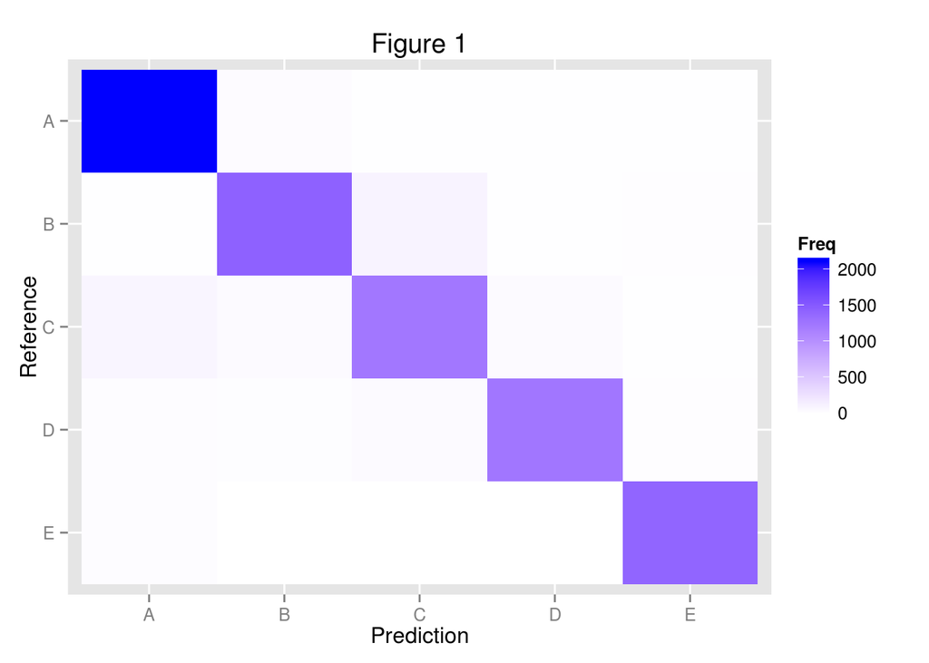

```r
cfdf<-as.data.frame(cf$table)
cfdf$Reference <- factor(cfdf$Reference, levels = rev(levels(cfdf$Reference)))
plot <- ggplot(cfdf)
plot + geom_tile(aes(x=Prediction, y=Reference, fill=Freq)) + scale_fill_gradient(low="white", high="blue") + labs(title = "Figure 1")
```

```r
rawTestPredict<-predict(modFit,newdata=preRawTesting,na.action=na.pass)
#length(testPredict);length(preTesting$classe);length(testing$classe)
#confusionMatrix(preTesting$classe,testPredict)
rawTestPredict
```

```
##  [1] B A B A A E D B A A B C B A E E A B B B
## Levels: A B C D E
```